# 6.4 Automatic Differentiation

code

share

► [Chapter 6: First order methods](https://jermwatt.github.io/mlrefined/index.html)  
6.4 Automatic Differentiation

Throughout the remainder of this text we will often need to compute the first derivative(s) of a differentiable function in order to employ the sort of optimization algorithms we detail in this as well as the following Chapter. Because we will need to make such calculations for a wide variety of functions we will be employing an Automatic Differentiator - i.e., a calculator that computes derivative(s) of an input function. We describe the construction of Automatic Differentiators extensively in Chapter 3, but here it suffices to understand the context in which we are using this tool along with a basic fact about how this tool performs computations (see Section 3.11 for a complete introduction to the basic functionality of the particular gradient calculator we will be using here).

## 6.4.1 Why use an Automatic Differentiator?

Even though we will often be using a calculator to compute our gradients, you should still understand the basic rules of differentiation described in Section 3.3 since we will need them to compute derivatives by hand when discussing certain fundamental paradigms and in the structural analysis of certain functions. For example, in Section 6.1 we studied the first order condition for optimality, where it made sense to study a number of hand-computed examples. We will also see the need for hand-computed derivatives in the next Section where we discuss mathematically derived steplength values for gradient descent.

So, how much hand-computing mastery do you need going forward? Not much: just make sure you can follow the sort of examples shown in Section 6.1. In other words, you need a proficiency level on par with your ability to perform multiplication by hand. You can compute simple multiplication examples quickly yourself because you understand the principles of arithmetic - e.g., computing $8 \times 7$ or $5 \times 2$ is a breeze - but how do you compute $140,283,197,523 \times 224,179,234,112$, and fast? By using a calculator. This is exactly how we treat derivative taking: for simple examples, when we need to, we do it ourselves. Otherwise we just use a calculator - called an Automatic Differentiator.

We will be using an Automatic Differentiator in most implementations of our optimization algorithms because it is both convenient and computationally efficient. We certainly could have computed a number of the derivative(s) used in the examples of this Section 'by hand'. But there is little added value in spending our limited time / resources doing this if we can use a calculator to get the same results - especially since our focus here is on understanding and implementing optimization algorithms for the purposes of machine learning / deep learning. Moreover, the gradient evaluations we perform via an Automatic Differentiator are very efficient compared with how we might implement for a particular function 'by hand' for most cases.

Finally remember one important fact about how the Automatic Differentiator works (as detailed in Chapter 3). When we evaluate the gradient $\nabla g\left(\mathbf{w}^{\star}\right)$ of a function $g\left(\mathbf{w}\right)$ at some point $\mathbf{w}^{\star}$ using an Automatic Differentiator, the corresponding function evaluation $g\left(\mathbf{w}^{\star}\right)$ is always computed along the way. One can think of the cost function evaluation as a bi-product of our gradient computation, we always get it 'for free' when we evaluate a gradient.

This is important because together over a single run these function evaluations constitute our *cost function plot*, the primary debugging tool we have to ensure e.g., we have tuned the steplength parameter correctly. The cost function plot is one of our primary debugging tools we will use throughout the text with all of our optimization algorithms, and there is no need to re-compute the function evaluations after a run since we can collect them along the way whenever we employ an Automatic Differentiator.

## 6.4.2 Getting to know Autograd

`pip install autograd`

to install the entire package at your terminal.

In this short Section we show off a few examples highlighting the basic usage of the `autograd` automatic differentiator (which by default employs the *reverse-mode* of automatic differentiation - i.e., *backpropogation*) - including how to compute derivatives of single input functions, and partial derivatives / complete gradients of multi-input functions. Note: If you follow along in the `Jupyter` notebook version of this Section you can also see how to use the `matplotlib` plotting library to produce two-dimensional and three-dimensional plots.

**Note:** We highly recommended that you install the Anaconda `Python` 3 distribution - which you can [find here](https://www.anaconda.com/download/). This standard `Python` distribution includes a number of useful libraries - including `numpy`, `matplotlib`, and `Jupyter` itself - and makes it considerably easier to install additional libraries as well.

#### Example 1. Computing derivatives of single-input functions using `autograd`

Since `autograd` is specially designed to automatically compute the derivative(s) of `numpy` code, it comes with its own distribution of `numpy` that wrappers and slightly modified versions of certain functionalities. You can use `autograd`'s version of `numpy` exactly like you would the standard version - nothing about the user interface has been changed. To import this `autograd` wrapped version of `numpy` use the line below.

```python
# import statement for autograd wrapped numpy
import autograd.numpy as np
```

There are two common ways of defining functions in `Python`. First the the standard `def` named `Python` function declaration like below

```python
# a named Python function
def g(w):
    return np.tanh(w)
```

WIth this declaration `Python` now understands `g` as its own function, so it can be called as follows.

```python
# how to use the 'tanh' function
w_val = 1.0   # a test input for our 'sin' function
g_val = g(w_val)
print (g_val)
```

```
0.761594155956
```

You can also create "anonymous" functions in `Python` - functions you can define in a single line of code - by using the `lambda` command. We can produce the same function using lambda as shown below.

```python
# how to use 'lambda' to create an "anonymous" function - just a pithier way of writing functions in Python
g = lambda w: np.tanh(w)
```

We can then use it with a test value as shown below.

```python
# how to use the 'sin' function written in 'anonymous' format
w_val = 1.0
g_val = g(w_val)
print (g_val)
```

```
0.761594155956
```

And - of course - regardless of how we define our function in `Python` it still amounts to the same thing mathematically/computationally.

Notice on subtlety here (regardless of which kind of `Python` function we use): the data-type returned by our function matches the type we input. Above we input a `float` value to our function, and what is returned is also a `float`. If we input the same value as a `numpy` array then numerically our function of course computes the same evaluation, but evaluation is returned as a `numpy` array as well. We illustrate this below.

```python
# if we input a float value into our function, it returns a float
print (type(w_val))
print (type(g_val))

# if we input a numpy array, it returns a numpy array
w_val = np.array([1.0])
g_val = g(w_val)
print (g_val)
print (type(w_val))
print (type(g_val))
```

```
<class 'float'>
<class 'numpy.float64'>
[ 0.76159416]
<class 'numpy.ndarray'>
<class 'numpy.ndarray'>
```

This factoid has no immediate consequences, but it is worth taking note of to avoid confusion (when e.g., comparing the output when evaluating at single points - which are naturally dealt with by inputing a `float` - versus multiple points, which is more naturally dealt with by inputing a `numpy` array). Much later - when we are constructing considerably complex functions we need to differentiate - this will be something to keep in mind for de-bugging purposes.

In any case - we can visualize either version of our function by using `matplotlib` assets, as shown below. Here we will plot the `lambda` version - over a fine range of points on the interval $[-5,5]$.

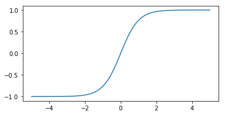

Now, using `autograd` we can then compute the derivative of our function here automatically. Below we show the proper import statement and manner of using the gradient calculator called `grad`.

```python
# import statment for gradient calculator
from autograd import grad
```

To use `grad` we simply pass in the function we wish to differentiate. `grad` works by *explicitly* computing the computation graph of our input, giving us a `Python` function for its derivative that we can then evaluate wherever we want. Here we call the derivative function of our input `dgdw`.

```python
# create the derivative/gradient function of g --> called dgdw
dgdw = grad(g)
```

The gradient function can be evaluated like our original `Python` function - as shown below.

```python
# evaluate the gradient function at a point
w_val = 1.0
print (dgdw(1.0))
```

```
0.419974341614
```

Just as with our original `Python` function we can then evaluate our gradient `dgdw` over a fine range of input and plot the result. We do this below, plotting the original function as well for comparison.

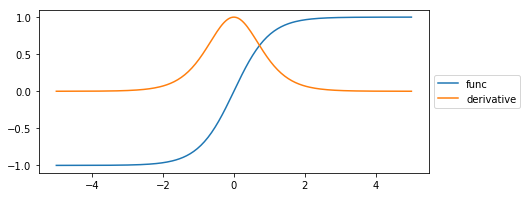

We can compute higher order derivatives of our input function by using the same `autograd` functionality recursively, i.e., by plugging in the derivative `dgdw` into `autograd`'s `grad` function. Doing this once gives us the second derivative as shown below.

```python
# compute the second derivative of our input function
dgdw2 = grad(dgdw)
```

We can then plot the input function, as well as the first and second derivatives, as shown below.

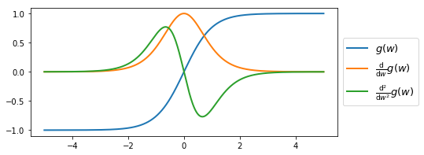

#### Example 2. Remember, whenever you use an Automatic Differentiatior to evaluate a gradient you are explicitly evaluating the function as well

Above you may notice that the derivative function `dgdw` we have constructed returns only the derivative evaluation, and not the function evaluation itself (we have computed this separately when e.g., plotting a range of function / derivative values above). However as we described in the previous Sections, an Automatic Differentiator will always need to compute the value of the function itself whenever we use it to compute a derivative / gradient evaluation. *So - in other words - whenever we evaluate the gradient, we get the function evaluation for free*. This is a very handy technical fact which will save us a ton of computation later on when we discuss e.g., supervised learning models.

We can already see an example of the waste - e.g., in the previous example when we evaluated / plotted the function and its first derivative there was no need to actually evaluate the function explicitly since these computations are already performed when we evaluate the gradient. However when we used `autograd`'s `grad` functionality to compute the gradient of our function in the previous example, and then evaluated it at a single point, `grad` only returned a single value: the evaluation of the derivative. No function evaluation was returned - so where is the mirror function evaluation? Well the function evaluation is indeed being computed 'under the hood' of `grad`, it is simply not being returned via this method. This is a design choice made by the authors of `autograd` to keep the interface of `grad` - their introductary Automatic Differentiation method - easy to pick up and use for a wide audience. Later when the need to re-compute function evaluations becomes quite costly we will use this `autograd` method exclusively (one can view the entire list of `autograd` [methods available here](https://github.com/HIPS/autograd/blob/master/autograd/differential_operators.py).

Now there is another `autograd` method called `value_and_grad` that returns everything computed 'under the hood' - both the derivative(s) and function evaluations. Below we use this `autograd` functionality to re-produce the previous example first derivative calculations.

```python
# how to use 'lambda' to create an "anonymous" function - just a pithier way of writing functions in Python
g = lambda w: np.tanh(w)
```

```python
# import statment for gradient calculator - this method will return both
# derivative and function evaluations (the latter always being computed 'under
# the hood')
from autograd import value_and_grad
```

```python
# create the derivative/gradient function of g --> called dgdw
dgdw = value_and_grad(g)
```

We have our derivative function `dgdw` above computed now using `value_and_grad`. Below we plug in a single point into this derivative function, and what is returned is both the function (left value) and derivative (right value) evaluation. This function evaluation comes 'for free' whenever we evaluate the derivative - we need not evaluate the function itself again.

```python
# evaluate the gradient function at a point
w_val = 1.0
print (dgdw(1.0))
```

```
(0.76159415595576485, 0.41997434161402608)
```

Now we use this to plot both the function and derivative over the same range used in the previous example - again without re-computing the function evaluations.

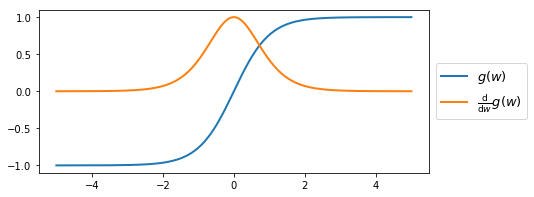

#### Example 3. Computing Taylor series approximations

Using `autograd` we can quickly illustrate Taylor series approximations of any single-input function. Below we illustrate the `tanh` function, along with a first order Taylor series approximation

\begin{equation} h(w) = g(w^0) + \frac{\mathrm{d}}{\mathrm{d}w}g(w^0)(w - w^0) \end{equation}

centered at the point $w^0 = 1$. First we produce this function and its first order Taylor series approximation in `Python` below.

```python
# create function / first derivative
g = lambda w: np.tanh(w)
dgdw = grad(g)

# create first order taylor series approximation - as a Python function
# here w_0 is the center point of the expansion
first_order = lambda w_0,w: g(w_0) + dgdw(w_0)*(w - w_0)
```

Now we evaluate and plot the function and its first order approximation. The function is shown in black, its first order approximation centered at $w_0 = 1$ is shown in green, and the point of tangency with the function shown as a red point.

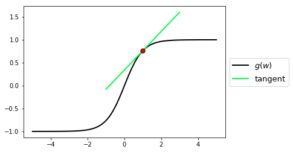

Its just as easy to show the second order Taylor series approximation as well, whose formula is given as

\begin{equation} h(w) = g(w^0) + \frac{\mathrm{d}}{\mathrm{d}w}g(w^0)(w - w^0) + \frac{1}{2}\frac{\mathrm{d}^2}{\mathrm{d}w^2}g(w^0)(w - w^0)^2. \end{equation}

Below we compute and plot both the `tanh` function, along with its first and second order Taylor series approximations at the point $w^0 = 1$.

```python
# create second derivative function
dgdw2 = grad(dgdw)

# create second order taylor series approximation - as a Python function
# here w_0 is the center point of the expansion
second_order = lambda w_0,w: g(w_0) + dgdw(w_0)*(w - w_0) + 0.5*dgdw2(w_0)*(w - w_0)**2
```

The first and second order approximations are shown below in green and blue respectively, with the point of expansion again shown as a red point.

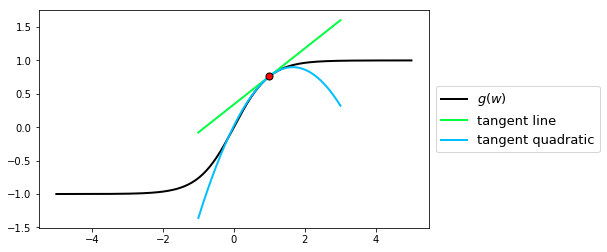

#### Example 4. Computing individual partial derivatives of a multi-input functions using `autograd`

There are a number of ways we can go about using `autograd` to compute the partial derivatives of a multi-input function. First lets look at how to use `autograd` to compute partial derivatives individually, or one-at-a-time.

As an example lets look at the following function

\begin{equation} g\left(w_1,w_2\right) = \text{tanh}\left(w_1w_2\right). \end{equation}

This simple function takes in two inputs - $w_1$ and $w_2$ - and here we have written them out *explicitly*.

Below we translate this function into `Python` - note here we use the longer form `def` version of a `Python` function, but we could of course use the pithier `lambda` version if we like.

```python
# a simple multi-input function defined in python
def g(w_1,w_2):
    return np.tanh(w_1*w_2)
```

Taking in two inputs, this function lives in three dimensions. Below we plot it over a small range of its input.

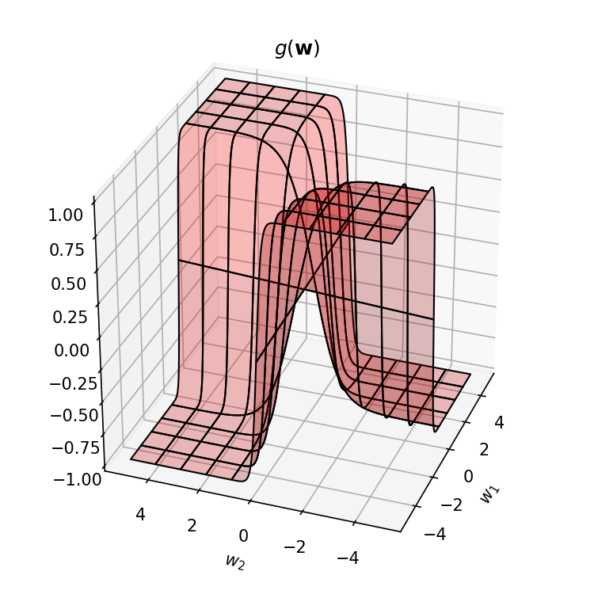

Now we use `autograd`'s `grad` function to compute the two partial derivative functions here. In this example since our function $g$ takes in two inputs its gradient consists of two partial derivative functions each of which takes in the two inputs $w_1$ and $w_2$ as well

\begin{equation} \nabla g\left(w_1,w_2\right) = \begin{bmatrix} \frac{\partial}{\partial w_1}g\left(w_1,w_2\right) \\ \frac{\partial}{\partial w_2}g\left(w_1,w_2\right) \end{bmatrix}. \end{equation}

We can use the same `autograd` functionality used previously with single input functions here, with one simple addition - now we specify which partial derivative function we wish to construct. If we use the exact same call we used e.g., in the previous example and write

`grad(g)`

here - since our function takes in two inputs - this will return the *first* partial derivative $\frac{\partial}{\partial w_1}g\left(w_1,w_2\right)$. This is the *default* setting of each automatic differentiation method in `autograd`.

Alternatively to compute this partial derivative function we can explicitly pass a second argument to `grad` - or any of the other `autograd` methods - which is a simple index denoting which partial derivative we want. To create the same (first) partial derivative this way we pass in the index `0` - since `Python` indexing starts with `0`

`grad(g,0)`

To construct the second partial derivative we use the same `Pythonic` language, but pass the second index `1`

`grad(g,1)`

More generally speaking, if $g$ took in $N$ inputs $w_1$ through $w_N$ we can construct its $n^{th}$ partial derivative using the same pattern as

`grad(g,n-1)`

and so on.

Back to our example - below define both partial derivatives using these commands below.

```python
# compute the gradient of our input function
dgdw1 = grad(g,0)
dgdw2 = grad(g,1)
```

These two partial derivative functions can now be used precisely as the original function $g$ in `Python`, which we do to produce plots of each as shown below.

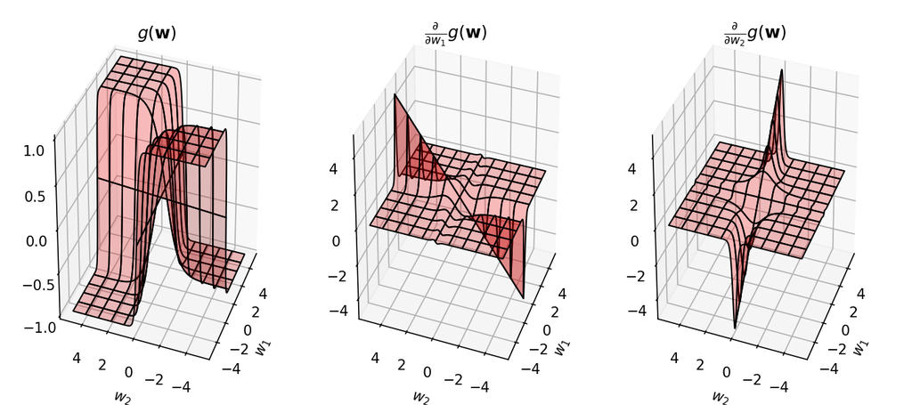

#### Example 5. Computing several derivatives or the full gradient of a multi-input functions using `autograd`

Building on the previous example, here we look at how to use `autograd` to construct several partial derivative functions or the entire gradient of a multi-input function. We do this via example, using the same of function employed in the previous example.

There are two ways to construct multiple partial derivative functions at once - including the full gradient - using `autograd`. The first way is to simply index all the partial derivatives desired using the same sort of notation introduced previously. So here - for example - if we wish to construct the full gradient of our function (it has two partial derivatives) we tell `autograd` of this desire by feeding in the two indices $(0,1)$ as shown below

`grad(g,(0,1))`

More generally, for a function taking in $N$ inputs, to construct any subset of partial derivatives at once we use the same sort of indexing notation. Note: this usage applies to all methods in the `autograd` automatic differentiation library (like e.g., `value_and_grad`).

We do this below for the function shown in the previous example, producing a function for its complete gradient.

```python
# construct all partial derivative functions at once
nabla_g = grad(g,(0,1))
```

The second way to construct several derivatives at once using `autograd` is by writing a function in `numpy` where all the desired variables we wish to differentiate with respect to are all input into the function as a *single argument*. For example, if instead of writing out our function in `Python` as

```python
# a simple multi-input function defined in python
def g(w_1,w_2):
    return np.tanh(w_1*w_2)
```

where both $w_1$ and $w_2$ are fed in one-at-a-time, if we write it equivalently using vector-notation where $\mathbf{w} = \begin{bmatrix}w_1 \\ w_2 \end{bmatrix}$ as

```python
def g(w):
    return np.tanh(w[0]*w[1])
```

then the call

`grad(g)`

or equivalently

`grad(g,0)`

will produce derivatives of $g$ with respect to its *first argument* - which here will give us the complete gradient of $g$. Before that first argument was just $w_1$, but now in our new way of writing the function it is the complete set of inputs $\mathbf{w}$ (i.e., all partial derivatives of the function).

This indexing format holds more generally as well - if in the way we express a function in `numpy` it takes in $N$ inputs, the statement

`grad(g,n-1)`

computes the derivatives of the function with respect to whatever the $n^{th}$ input is - i.e., whether it is a single variable or multiple variables.

As another example, take the inner product function of two length $M$ vectors $\mathbf{a}$ and $\mathbf{b}$

\begin{equation} g\left(\mathbf{a},\mathbf{b}\right) = \mathbf{a}^T\mathbf{b} \end{equation}

Writing

`grad(g)`

or

`grad(g,0)`

gives us the partial derivative functions for all entries of $\mathbf{a}$. Likewise

`grad(g,1)`

gives us the partial derivative functions for all entries of $\mathbf{b}$.

© This material is not to be distributed, copied, or reused without written permission from the authors.